# VEGANScreener + metabolomics

Q5: Associations between PDI groups and the metabolome.

**This code is used to explore patterns in the metabolome profiles of vegans, particularly by exploring associations with their dietary records (PDI groups).**

The main parts of the analysis is composed of:

1. Canonical correlation analysis (CCA) - find linear combinations of **PDI groups** and metabolites that are maximally correlated. - SPCA
2. Mantel test - provides a global similarity measure - SPCA
3. Linear modeling - Metabolite ~ sex + bmi + age + country***PDI_group**
4. Network analysis - bipartite graph. Edges of the graph correspond to the significant associations (Estimates from LM).

# 1 Import

```r
metadata_df <- read.table(
  file =  "../../data/preprocessed/metadata_preprocessed_v3.tsv",
  header = TRUE)  %>%
  dplyr::filter(group=="VG")

lcms_df <- read.table(
  file= "../../data/preprocessed/metabolomics/lc_ms_preprocessed_INT_v3.tsv",
  check.names = FALSE)

nmr_df <- read.table(
  file = "../../data/preprocessed/metabolomics/nmr_preprocessed_INT_v3.tsv",
  check.names = FALSE)

spca_integrated_df <-  read.table(
  file = "../../data/preprocessed/metabolomics/spca_integrated_vegans_INT_v3.tsv",
  check.names = FALSE)

pdi_df <- as.data.frame(fread(
  file = "../../data/preprocessed/dietary/pdi/pdi_avg_residuals_scaled_v3.tsv")) %>%
  dplyr::select(-c(age,gender,bmi,eq_included_group,study_center,PDI_sweets_and_desserts_alt_avg))
```

```r
metadata_scaled_df <- metadata_df
metadata_scaled_df[,-c(1,3,5,6,8)] <- apply(metadata_df[,-c(1,3,5,6,8)],2,scale)
metadata_scaled_df <- metadata_scaled_df %>%
  mutate(sex=as.factor(sex),
         country=as.factor(country),
         group=as.factor(group),
         diet_supplements=as.factor(diet_supplements))
```

# 2 Descriptive statistics

## 2.1 Metadata

Summary of counts per diet group, country and sex:

```r
metadata_df %>% dplyr::group_by(country,sex) %>% count()
```

| country | sex | n |
| --- | --- | --- |
| BE | F | 54 |
| BE | M | 28 |
| CH | F | 23 |
| CH | M | 20 |
| CZ | F | 50 |
| CZ | M | 41 |
| DE | F | 51 |
| DE | M | 47 |
| ES | F | 28 |
| ES | M | 15 |

Basic plots for visualizing the distribution of selected variables:

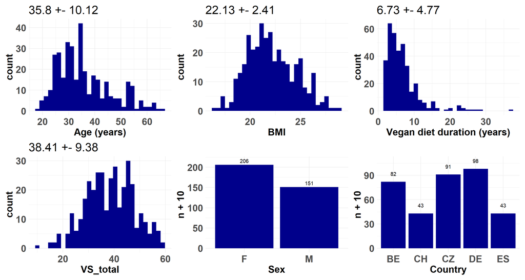

```r
plot_list <- list()
name <- c("Age (years)","BMI","Vegan diet duration (years)","VS_total")
i <- 1
for (col in c("age","bmi","vegan_duration","VS_total")){
  p <- ggplot(metadata_df) +
    geom_histogram(aes(x=!!sym(col)),fill="darkblue") +
    theme_minimal() +
    theme(axis.title = element_text(face="bold",size=20),
          axis.text=element_text(face="bold",size=20),
          title = element_text(face = "plain",size=20)) +
    xlab(name[i]) +
    ggtitle(paste(round(mean(metadata_df[,col],na.rm = TRUE),2),"+-", round(sd(metadata_df[,col],na.rm = TRUE),2)))

  plot_list[[length(plot_list)+1]] <- p
  i <- i + 1

}
i <- 1
name <- c("Sex","Country")
for (col in c("sex","country")){
  p <- ggplot(metadata_df) +
        theme_minimal() +
     theme(axis.title = element_text(face="bold",size=20),
          axis.text=element_text(face="bold",size=20)) +
  geom_text(data=metadata_df %>%
              dplyr::group_by(!!sym(col)) %>% count(), aes(x=!!sym(col),y=n+10,label=n)) +
    stat_count(aes(x=!!sym(col)),fill="darkblue") +
    xlab(name[i])

  plot_list[[length(plot_list)+1]] <- p

  i <- i+1
}

wrap_plots(plot_list)
```

## 2.2 PDI

Basic plots for visualizing the distribution:

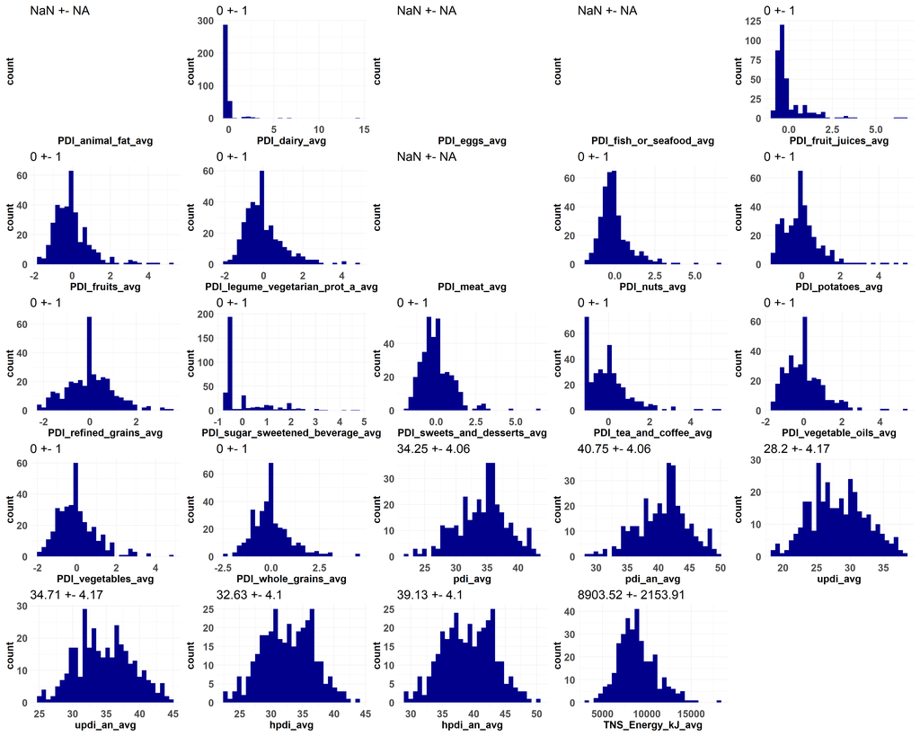

```r
plot_list <- list()
name <- colnames(pdi_df)[-1]
i <- 1
for (col in name){
  p <- ggplot(pdi_df) +
    geom_histogram(aes(x=as.numeric(!!sym(col))),fill="darkblue") +
    theme_minimal() +
    theme(axis.title = element_text(face="bold",size=20),
          axis.text=element_text(face="bold",size=20),
          title = element_text(face = "plain",size=20)) +
    xlab(name[i]) +
    ggtitle(paste(round(mean(pdi_df[,col],na.rm = TRUE),2),"+-", round(sd(pdi_df[,col],na.rm = TRUE),2)))
  plot_list[[length(plot_list)+1]] <- p
  i <- i + 1

}

wrap_plots(plot_list)
```

**We will remove the animal-related groups.**

```r
pdi_df <- pdi_df %>% dplyr::select(-c(PDI_animal_fat_avg,PDI_eggs_avg,PDI_fish_or_seafood_avg,PDI_meat_avg,PDI_dairy_avg))
```

# 3 Concatenated dataset

```r
concat_integrated_df <- cbind(lcms_df,nmr_df)
```

## 3.1 Mantel test

The Mantel test measures the correlation between two distance (or dissimilarity) matrices.

In our case:

Dataset 1: PDI profiles (e.g., pdi groups intake per client) Dataset 2: Metabolomic profiles (e.g., metabolite concentrations per client)

The Mantel test asks: Are clients who eat similarly also similar in their metabolome?

```r
#nutri <- pdi_df[,c(-19,-20)] %>% column_to_rownames("study_id")
nutri <- pdi_df[,-c(14:21)] %>% column_to_rownames("study_id")

# delete the zero variance columns
cols_to_del <- which(apply(nutri, 2, var, na.rm = TRUE) == 0)
if (length(cols_to_del)>0){
  nutri <- nutri[,-cols_to_del]

}
```

### 3.1.1 Euclidean distance

**Simple Mantel test**

The Mantel statistic r: 0.1303 (p=0.001).

```r
# Compute distance matrices (e.g., Euclidean)
dist_nutri <- vegdist(nutri,method = "euclidean",na.rm = TRUE)
dist_metabo <-  vegdist(concat_integrated_df,method="euclidean",na.rm = TRUE)

anyNA(dist_nutri)
```

```
[1] FALSE
```

```r
anyNA(dist_metabo)
```

```
[1] FALSE
```

```r
# Mantel test
mantel_result <- mantel(dist_nutri, dist_metabo, method = "spearman",
                        permutations = 999)
print(mantel_result)
```

```
Mantel statistic based on Spearman's rank correlation rho

Call:
mantel(xdis = dist_nutri, ydis = dist_metabo, method = "spearman",      permutations = 999)

Mantel statistic r: 0.1303
      Significance: 0.001

Upper quantiles of permutations (null model):
   90%    95%  97.5%    99%
0.0451 0.0588 0.0721 0.0810
Permutation: free
Number of permutations: 999
```

```r
dist_nutri_df <- dist_nutri %>%
  as.matrix() %>%
  as_tibble(rownames = "A") %>%
  pivot_longer(cols = -A, names_to = "B", values_to = "nutri") %>%
  mutate_if(is.character, str_trim)

dist_metabo_df <- dist_metabo %>%
  as.matrix() %>%
  as_tibble(rownames = "A") %>%
  pivot_longer(cols = -A, names_to = "B", values_to = "metabo") %>%
  mutate_if(is.character, str_trim)
```

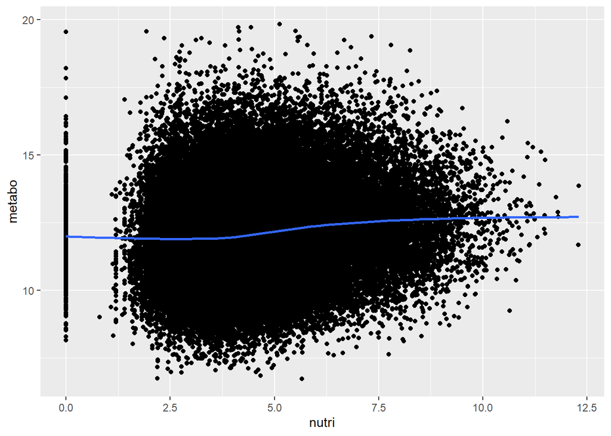

```r
combined <- inner_join(dist_nutri_df,dist_metabo_df, by=c("A","B")) %>%
  dplyr::filter(A!=B) %>%
  dplyr::filter(A < B)

ggplot(combined,aes(nutri,metabo)) +
  geom_point() +
  geom_smooth(se=FALSE)
```

```r
cor.test(combined$nutri,combined$metabo,method = "spearman")
```

```
    Spearman's rank correlation rho

data:  combined$nutri and combined$metabo
S = 3.7195e+13, p-value < 2.2e-16
alternative hypothesis: true rho is not equal to 0
sample estimates:
      rho
0.1302895
```

**Partial Mantel test**

The partial mantel is also a correlation test between two matrices, but controlling for the effect of a third distance matrix. This control is done by calculating the correlation between the residuals of each of the two main distance matrices after a linear regression on the third distance matrix.

```r
country_vec <- metadata_df$country  # same order as in your data

dist_country <- as.dist(
  outer(country_vec, country_vec, FUN = Vectorize(function(x, y) as.numeric(x != y)))
)

mantel.partial(dist_nutri, dist_metabo, dist_country, permutations = 999,method = "spearman")
```

```
Partial Mantel statistic based on Spearman's rank correlation rho

Call:
mantel.partial(xdis = dist_nutri, ydis = dist_metabo, zdis = dist_country,      method = "spearman", permutations = 999)

Mantel statistic r: 0.1273
      Significance: 0.001

Upper quantiles of permutations (null model):
   90%    95%  97.5%    99%
0.0408 0.0583 0.0673 0.0820
Permutation: free
Number of permutations: 999
```

## 3.2 PERMANOVA

```r
df_to_test <- merge(pdi_df,metadata_scaled_df,by="study_id",all=TRUE)
```

```r
vars_to_test <- colnames(nutri)

adonis_result_all <- data.frame(Var=NA,
                                Df=NA,
                                SumOfSqs=NA,
                                R2=NA,
                                `F`=NA,
                                `Pr(>F)`=NA,
                                check.names = FALSE)
for (variable in vars_to_test){
  metadata_sub_df <- df_to_test %>% dplyr::select(all_of(
    c("study_id","sex", "bmi","age","VS_total","vegan_duration", variable))) %>% drop_na()
  sub_spca <- spca_integrated_df[as.character(metadata_sub_df$study_id),]

  # Create Euclidean distance matrix
  dist_mat <- vegdist(sub_spca,
                    method = "euclidean")

  # Test
  adonis_result <- adonis2(
  as.formula(paste0("dist_mat ~ sex + bmi + age + vegan_duration + ", variable)),
  data = metadata_sub_df ,
  permutations = 999,
  by="terms")

  adonis_result_all <- rbind(adonis_result_all,as.data.frame(adonis_result) %>%
                               rownames_to_column("Var"))
}


adonis_result_all <- adonis_result_all %>% dplyr::filter(grepl("PDI_",Var))
adonis_result_all$adjusted_p <- p.adjust(adonis_result_all$`Pr(>F)`,method = "BH")

knitr::kable(adonis_result_all)
```

| Var | Df | SumOfSqs | R2 | F | Pr(>F) | adjusted_p |
| --- | --- | --- | --- | --- | --- | --- |
| PDI_fruit_juices_avg | 1 | 66.23464 | 0.0033757 | 1.2930435 | 0.174 | 0.1898182 |
| PDI_fruits_avg | 1 | 232.83134 | 0.0118665 | 4.5878827 | 0.001 | 0.0017143 |
| PDI_legume_vegetarian_prot_a_avg | 1 | 286.02136 | 0.0145774 | 5.6528579 | 0.001 | 0.0017143 |
| PDI_nuts_avg | 1 | 114.39733 | 0.0058304 | 2.2392820 | 0.013 | 0.0173333 |
| PDI_potatoes_avg | 1 | 49.08896 | 0.0025019 | 0.9574097 | 0.480 | 0.4800000 |
| PDI_refined_grains_avg | 1 | 161.68128 | 0.0082402 | 3.1732139 | 0.001 | 0.0017143 |
| PDI_sugar_sweetened_beverage_avg | 1 | 156.24837 | 0.0079634 | 3.0656545 | 0.001 | 0.0017143 |
| PDI_sweets_and_desserts_avg | 1 | 205.58022 | 0.0104776 | 4.0447183 | 0.001 | 0.0017143 |
| PDI_tea_and_coffee_avg | 1 | 117.06581 | 0.0059664 | 2.2918575 | 0.006 | 0.0090000 |
| PDI_vegetable_oils_avg | 1 | 93.27510 | 0.0047539 | 1.8236747 | 0.024 | 0.0288000 |
| PDI_vegetables_avg | 1 | 195.01941 | 0.0099394 | 3.8346682 | 0.001 | 0.0017143 |
| PDI_whole_grains_avg | 1 | 157.02998 | 0.0080032 | 3.0811245 | 0.001 | 0.0017143 |

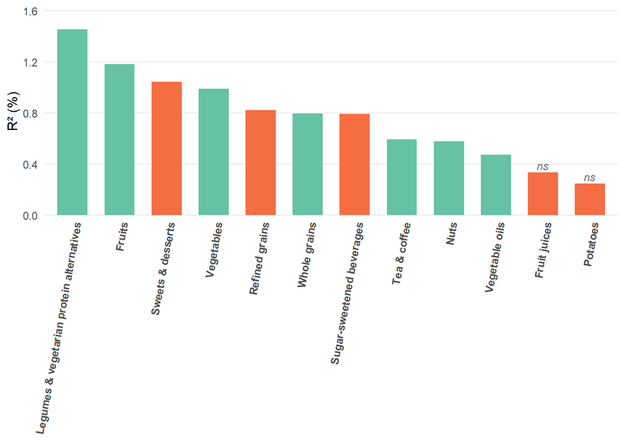

```r
labels <- c(
  "PDI_legume_vegetarian_prot_a_avg" = "Legumes & vegetarian protein alternatives",
  "PDI_sweets_and_desserts_avg"      = "Sweets & desserts",
  "PDI_sugar_sweetened_beverage_avg" = "Sugar-sweetened beverages",
  "PDI_fruits_avg" = "Fruits",
  "PDI_vegetables_avg" = "Vegetables",
  "PDI_nuts_avg" = "Nuts",
  "PDI_whole_grains_avg" = "Whole grains",
  "PDI_refined_grains_avg" = "Refined grains",
  "PDI_vegetable_oils_avg" = "Vegetable oils",
  "PDI_tea_and_coffee_avg" = "Tea & coffee",
  "PDI_fruit_juices_avg" = "Fruit juices",
  "PDI_potatoes_avg" = "Potatoes",
  "PDI_nuts_avg" = "Nuts")

adonis_result_all$Var <- labels[adonis_result_all$Var]
adonis_result_all$Category <- c("unhealthy","healthy","healthy","healthy",
                                "unhealthy","unhealthy","unhealthy","unhealthy",
                                "healthy","healthy","healthy","healthy")

adonis_result_all$Var <- factor(
  adonis_result_all$Var,
  levels = adonis_result_all$Var[order(adonis_result_all$R2,decreasing = TRUE)]
)

p_permanova <- ggplot(adonis_result_all, aes(x = Var, y = R2*100, fill = Category)) +
  geom_col(width = 0.65, colour = "white", linewidth = 0.3) +
  # mark non-significant bars with "ns"
  geom_text(data = filter(adonis_result_all, adjusted_p > 0.05),
            aes(label = "ns", y = R2*100 + 0.05),
            size = 3, colour = "grey40", fontface = "italic") +
  scale_fill_manual(values = c("healthy"= "#66c2a5","unhealthy"= "#f46d43"), guide = "none") +
  scale_y_continuous(expand = expansion(mult = c(0, 0.12))) +
  labs(x = NULL, y = "R² (%)") +
  theme_minimal(base_size = 11) +
  theme(
    strip.text       = element_text(face = "bold", size = 10),
    panel.grid.major.x = element_blank(),
    panel.grid.minor   = element_blank(),
    axis.text.x      = element_text(face = "bold",angle=80,hjust = 1),
    plot.title       = element_blank()
  )
p_permanova
```

## 3.3 Network analysis

We want to model each metabolite as a function of sex, BMI, age, country, and each food group. Keep the estimated effect (and significance) of each food group on each metabolite.Then, we will use those significant effects to construct a bipartite network, where:

- one node type = metabolites
- other node type = food groups
- edges = significant relationships from the regression models.

Then we’ll analyze and visualize that network.

```r
nutri <- pdi_df[,-c(14:21)] %>% column_to_rownames("study_id")

# delete the zero variance columns
cols_to_del <- which(apply(nutri, 2, var, na.rm = TRUE) == 0)
if (length(cols_to_del)>0){
  nutri <- nutri[,-cols_to_del]
}

# delete the zero variance columns
nutri <- nutri %>%
  rownames_to_column("study_id")

metadata_for_lm <- merge(nutri,metadata_scaled_df,by="study_id",all=TRUE)

concat_for_uni <- merge(
  concat_integrated_df %>% rownames_to_column("study_id"),
  metadata_for_lm,
  by="study_id",all = TRUE)
```

### 3.3.1 LM

For each metabolite and PDI group, calculate:

Metabolite ~ sex + bmi + age + country + PDI_group

```r
results_list <- lapply(colnames(concat_integrated_df),
                       function(x) fit_netglm(x,concat_for_uni,
                                           tested_variable = "pdi_groups"))

results_df <- do.call(rbind, results_list)

results_df <- results_df %>%
  dplyr::mutate(p_adj = p.adjust(`p.value`, method = "BH"))

pdi_effects <- results_df %>% dplyr::filter(term %in% colnames(nutri))

concat_significant_cat <-  pdi_effects %>%
  filter(p_adj < 0.05)

concat_significant_cat
```

| term | estimate | std.error | statistic | p.value | Metabolite | p_adj |
| --- | --- | --- | --- | --- | --- | --- |
| PDI_tea_and_coffee_avg | 0.1843337 | 0.05455448 | 3.378892 | 8.102749e-04 | Caffeine | 3.038531e-02 |
| PDI_nuts_avg | -0.1737589 | 0.05274441 | -3.294356 | 1.087878e-03 | PC.32.1. | 3.376172e-02 |
| PDI_sweets_and_desserts_avg | 0.1641231 | 0.05307209 | 3.092456 | 2.145466e-03 | PC.32.1. | 4.217335e-02 |
| PDI_whole_grains_avg | -0.1782685 | 0.05403075 | -3.299389 | 1.069144e-03 | PC.32.1. | 3.376172e-02 |
| PDI_legume_vegetarian_prot_a_avg | -0.2011944 | 0.05261558 | -3.823855 | 1.556550e-04 | PC.34.1. | 1.298159e-02 |
| PDI_sweets_and_desserts_avg | 0.2630599 | 0.05112217 | 5.145712 | 4.463101e-07 | PC.34.1. | 1.004198e-04 |
| PDI_vegetables_avg | -0.1914643 | 0.05236570 | -3.656292 | 2.954037e-04 | PC.34.1. | 1.661646e-02 |
| PDI_whole_grains_avg | -0.1634583 | 0.05337463 | -3.062472 | 2.366137e-03 | PC.34.1. | 4.436507e-02 |
| PDI_nuts_avg | 0.1747668 | 0.05233663 | 3.339283 | 9.309120e-04 | PC.36.2. | 3.351283e-02 |
| PDI_fruits_avg | 0.1763106 | 0.05031175 | 3.504363 | 5.174889e-04 | SM.d33.1. | 2.328700e-02 |

[output cut: 42 more lines]

```r
results_all <- pdi_effects

# save
write.table(results_all,"../results/vegan/Q5_PDIgroups/lm_continous_all.tsv",
            row.names = FALSE,
            quote=FALSE,
            sep="\t")
```

### 3.3.2 Graph construction

**Edge list**

```r
edges <- pdi_effects %>%
  dplyr::filter(p_adj < 0.05) %>%
  dplyr::select(from = term, to = Metabolite,
         estimate = estimate) %>%
  dplyr::mutate(from=as.character(from),
         weight=abs(estimate))

edges$from <- as.character(edges$from)
edges$to   <- as.character(edges$to)
```

**Nodes table**

```r
pdis <- as.character(unique(edges$from))
metabs <- as.character(unique(edges$to))

nodes <- data.frame(
  name = c(pdis, metabs),
  type = c(rep(TRUE, length(pdis)), rep(FALSE, length(metabs))) # TRUE = tertile, FALSE = metabolite
)
```

**Build igraph object**

```r
g <- graph_from_data_frame(d = edges, vertices = nodes, directed = FALSE)
```

**Visualize**

```r
categories <- list(
  "healthy" = c("PDI_fruits_avg",
                "PDI_legume_vegetarian_prot_a_avg",
                "PDI_nuts_avg",
                "PDI_tea_and_coffee_avg",
                "PDI_vegetable_oils_avg",
                "PDI_vegetables_avg",
                "PDI_whole_grains_avg"),

  "unhealthy" = c("PDI_fruit_juices_avg",
                "PDI_refined_grains_avg",
                "PDI_potatoes_avg",
                "PDI_sugar_sweetened_beverage_avg",
                "PDI_sweets_and_desserts_avg",
                "PDI_sweets_and_desserts_alt_avg"))
```

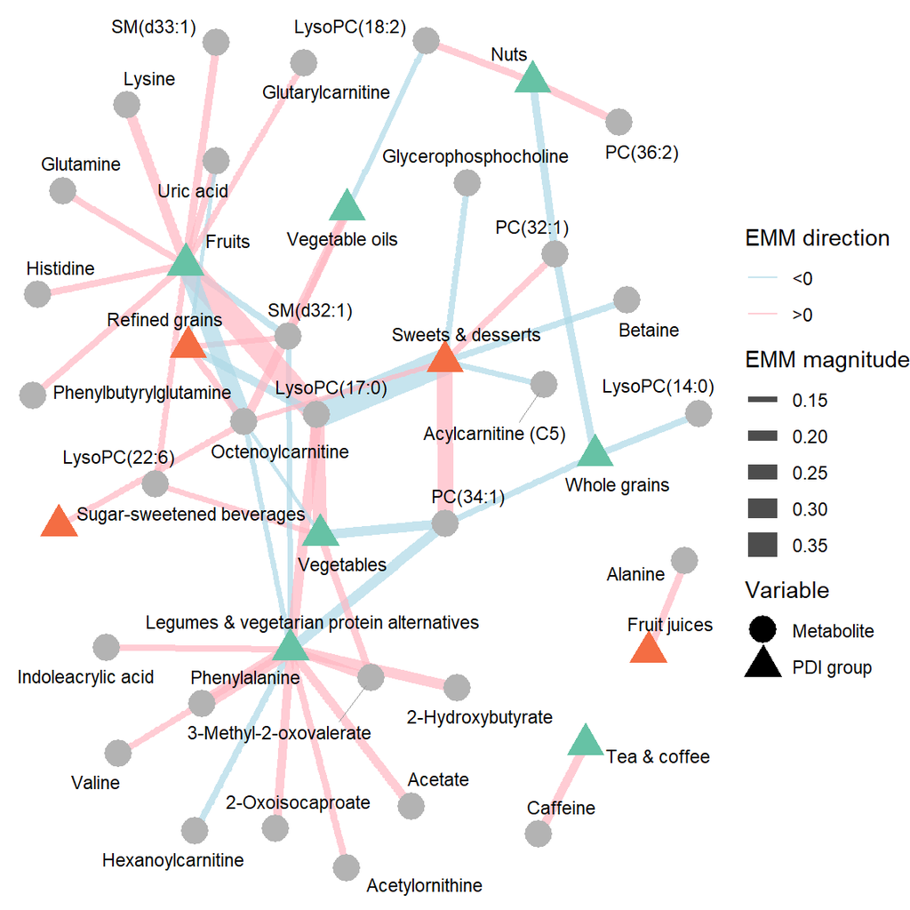

```r
set.seed(123)
pdi_colors <- colorRampPalette(
  c("#2596be","#9e0142","#d53e4f","#f46d43",
    "#fdae61","#e6f598","#66c2a5","#5e4fa2"))(12)

pdi_colors <- c(rep("#66c2a5",length(categories$healthy)),
                rep("#f46d43",length(categories$unhealthy)))

names(pdi_colors) <- c(categories$healthy,categories$unhealthy)

# Assign colors to nodes: countries get their color, metabolites gray
V(g)$color <- ifelse(V(g)$type,
                     pdi_colors[V(g)$name],
                     "gray70")

node_labels <- c(
  "PDI_legume_vegetarian_prot_a_avg" = "Legumes & vegetarian protein alternatives",
  "PDI_sweets_and_desserts_avg"      = "Sweets & desserts",
  "PDI_sugar_sweetened_beverage_avg" = "Sugar-sweetened beverages",
  "PDI_fruits_avg" = "Fruits",
  "PDI_vegetables_avg" = "Vegetables",
  "PDI_nuts_avg" = "Nuts",
  "PDI_whole_grains_avg" = "Whole grains",
  "PDI_refined_grains_avg" = "Refined grains",
  "PDI_vegetable_oils_avg" = "Vegetable oils",
  "PDI_tea_and_coffee_avg" = "Tea & coffee",
  "PDI_fruit_juices_avg" = "Fruit juices",
  "PDI_nuts_avg" = "Nuts",
  "Indoleacrylic.acid"            = "Indoleacrylic acid",
    "Acetylornithin"                = "Acetylornithine",        # NB: source typo (missing 'e'), not a dot issue
    "Ergothionenine"                = "Ergothioneine",          # NB: source typo, not a dot issue
    "Betaine"                       = "Betaine",
    "Asparagine"                    = "Asparagine",
    "Formate"                       = "Formate",
    "Glutamylglutamine"             = "Glutamylglutamine",
    "Hydroxydecanoylcarnitine"      = "Hydroxydecanoylcarnitine",
    "Hydroxyoctanoylcarnitine"      = "Hydroxyoctanoylcarnitine",
    "Glycine"                       = "Glycine",
    "3-Methyl-2-oxovalerate"        = "3-Methyl-2-oxovalerate",
    "Acetate"                       = "Acetate",
    "Citrate"                       = "Citrate",
    "Octenoylcarnitine"             = "Octenoylcarnitine",
    "Dodecenoylcarnitine"           = "Dodecenoylcarnitine",
    "Dimethylamine"                 = "Dimethylamine",
    "Uric.acid"                     = "Uric acid",
    "Alanine"                       = "Alanine",
    "3-Hydroxybutyrate"             = "3-Hydroxybutyrate",
    "Glucose"                       = "Glucose",
    "Hydroxybutyrylcarnitine"       = "Hydroxybutyrylcarnitine",
    "Lactate"                       = "Lactate",
    "Tyrosine"                      = "Tyrosine",
    "Inosine"                       = "Inosine",
    "Histidine"                     = "Histidine",
    "Phenylalanine"                 = "Phenylalanine",
    "Threonine"                     = "Threonine",
    "Phenylalanylphenylalanine"     = "Phenylalanylphenylalanine",
    "Methylguanidine"               = "Methylguanidine",
    "Glycerophosphocholine"         = "Glycerophosphocholine",
    "Acetone"                       = "Acetone",
    "Caffeine"                      = "Caffeine",
    "Hexanoylcarnitine"             = "Hexanoylcarnitine",
    "Phenylbutyrylglutamine"        = "Phenylbutyrylglutamine",
    "Trimethyllysine"               = "Trimethyllysine",
    "Isoleucine"                    = "Isoleucine",
    "Carnitine"                     = "Carnitine",
    "2-Oxoisocaproate"              = "2-Oxoisocaproate",
    "Propionylcarnitine"            = "Propionylcarnitine",
    "Glutamine"                     = "Glutamine",
    "Creatinine"                    = "Creatinine",
    "Valine"                        = "Valine",
    "Butyrylcarnitine"              = "Butyrylcarnitine",
    "Glutarylcarnitine"             = "Glutarylcarnitine",
    "2-Hydroxybutyrate"             = "2-Hydroxybutyrate",
    "Pyruvate"                      = "Pyruvate",
    "Lysine"                        = "Lysine",
    "Tryptophan"                    = "Tryptophan",
    "Diaminonaphthalene"            = "Diaminonaphthalene",
    "Ascorbate"                     = "Ascorbate",

    # ---- lipids: dots restored to ( ) and : ----
    "PC.36.2."                      = "PC(36:2)",
    "LysoPC.18.2."                  = "LysoPC(18:2)",
    "SM.d42.2."                     = "SM(d42:2)",
    "PC.P.38.4."                    = "PC(P-38:4)",
    "PC.38.4."                      = "PC(38:4)",
    "SM.d38.2."                     = "SM(d38:2)",
    "PC.36.4."                      = "PC(36:4)",
    "SM.d34.1."                     = "SM(d34:1)",
    "LysoPC.14.0."                  = "LysoPC(14:0)",
    "PC.34.1."                      = "PC(34:1)",
    "PC.40.6."                      = "PC(40:6)",
    "LysoPC.22.6."                  = "LysoPC(22:6)",
    "PA.44.5."                      = "PA(44:5)",
    "PC.32.1."                      = "PC(32:1)",
    "LysoPC.P.16.0."                = "LysoPC(P-16:0)",
    "LysoPC.17.0."                  = "LysoPC(17:0)",
    "SM.d32.1."                     = "SM(d32:1)",
    "SM.d33.1."                     = "SM(d33:1)",

    # ---- acylcarnitine chain-length annotations ----
    "Acylcarnitine..C8."            = "Acylcarnitine (C8)",
    "Acylcarnitine..C5."            = "Acylcarnitine (C5)",

  # ---- VERIFY THESE: adducts / ambiguous combined names ----
  # The reconstruction below is my best guess; confirm against your raw list.
  "Citrulline..M.Na."             = "Citrulline (M+Na)",
  "CE.18.2..M.NH4.."              = "CE(18:2)[M+NH4]",
  "PC.20.3.OH.P.18.1."            = "PC(20:3-OH/P-18:1)",
  "PC.P.38.4..PC.O.38.5."         = "PC(P-38:4)/PC(O-38:5)")


# create a label attribute; fall back to the original name if not in the dict
V(g)$label <- ifelse(V(g)$name %in% names(node_labels),
                     node_labels[V(g)$name],
                     V(g)$name)

set.seed(123)
p <- ggraph(g, layout = "fr") +
  geom_edge_link(aes(width = abs(weight), color = estimate > 0), alpha = 0.7) +
  scale_edge_width_continuous(name = "EMM magnitude") +
  scale_edge_color_manual(
    values = c("lightblue", "lightpink"),
    name="EMM direction",
    labels = c("<0", ">0")) +
  geom_node_point(aes(shape=type,color = name), size = 6,,name="Node",labels=c("Metabolite","PDI group")) +
  scale_color_manual(values = setNames(V(g)$color, V(g)$name)) +  # node colors
  geom_node_text(aes(label = label), repel = TRUE, size = 3,
                 max.overlaps = Inf, box.padding = 0.6, point.padding = 0.4,
                 min.segment.length = 1, segment.size = 0.2,
                 segment.color = "grey60", seed = 123) +
  scale_shape_manual(name = "Variable",
                     values = c("FALSE" = 16, "TRUE" = 17),
                     labels = c("TRUE" = "PDI group", "FALSE" = "Metabolite"))  +
  guides(color = "none") + theme_void()

p
```

```r
f <- p
save(f,file="../results/vegan/figures/F5e_Network.RData")
```

### 3.3.3 Degree calculation

Interpretation

*High-degree PDI nodes (type == TRUE)*

→ These dietary variables are associated with many metabolites → Could suggest broad metabolic influence

*High-degree metabolite nodes (type == FALSE)*

→ These metabolites are associated with multiple food groups → Potential nutritional biomarkers

```r
# Calculate degree
deg <- degree(g, mode = "all")

# Add to node dataframe
node_degree_df <- data.frame(
  name = names(deg),
  degree = deg,
  type = V(g)$type
)

# Separate interpretation
food_nodes <- node_degree_df %>% dplyr::filter(type == TRUE)
metabolite_nodes <- node_degree_df %>% dplyr::filter(type == FALSE)

food_nodes %>% arrange(desc(degree))
```

|  | name | degree | type |
| --- | --- | --- | --- |
| PDI_legume_vegetarian_prot_a_avg | PDI_legume_vegetarian_prot_a_avg | 13 | TRUE |
| PDI_fruits_avg | PDI_fruits_avg | 11 | TRUE |
| PDI_sweets_and_desserts_avg | PDI_sweets_and_desserts_avg | 7 | TRUE |
| PDI_vegetables_avg | PDI_vegetables_avg | 5 | TRUE |
| PDI_refined_grains_avg | PDI_refined_grains_avg | 4 | TRUE |
| PDI_nuts_avg | PDI_nuts_avg | 3 | TRUE |
| PDI_whole_grains_avg | PDI_whole_grains_avg | 3 | TRUE |
| PDI_vegetable_oils_avg | PDI_vegetable_oils_avg | 3 | TRUE |
| PDI_tea_and_coffee_avg | PDI_tea_and_coffee_avg | 1 | TRUE |
| PDI_sugar_sweetened_beverage_avg | PDI_sugar_sweetened_beverage_avg | 1 | TRUE |

[output cut: 1 more lines]

```r
metabolite_nodes %>% arrange(desc(degree))
```

|  | name | degree | type |
| --- | --- | --- | --- |
| Octenoylcarnitine | Octenoylcarnitine | 7 | FALSE |
| LysoPC.17.0. | LysoPC.17.0. | 5 | FALSE |
| PC.34.1. | PC.34.1. | 4 | FALSE |
| SM.d32.1. | SM.d32.1. | 4 | FALSE |
| PC.32.1. | PC.32.1. | 3 | FALSE |
| LysoPC.22.6. | LysoPC.22.6. | 2 | FALSE |
| LysoPC.18.2. | LysoPC.18.2. | 2 | FALSE |
| Uric.acid | Uric.acid | 2 | FALSE |
| 3-Methyl-2-oxovalerate | 3-Methyl-2-oxovalerate | 2 | FALSE |
| Caffeine | Caffeine | 1 | FALSE |

[output cut: 20 more lines]

**Weighted degree** - Should reflect cumulative association magnitude, not just number of links.

```r
strength_vals <- strength(g, weights = E(g)$weight)

node_strength_df <- data.frame(
  name = names(strength_vals),
  strength = strength_vals,
  type = V(g)$type
)

# Separate interpretation
food_nodes <- node_strength_df %>% dplyr::filter(type == TRUE)
metabolite_nodes <- node_strength_df %>% dplyr::filter(type == FALSE)

food_nodes %>% arrange(desc(strength))
```

|  | name | strength | type |
| --- | --- | --- | --- |
| PDI_legume_vegetarian_prot_a_avg | PDI_legume_vegetarian_prot_a_avg | 2.3612537 | TRUE |
| PDI_fruits_avg | PDI_fruits_avg | 2.1340623 | TRUE |
| PDI_sweets_and_desserts_avg | PDI_sweets_and_desserts_avg | 1.4162359 | TRUE |
| PDI_vegetables_avg | PDI_vegetables_avg | 0.8992126 | TRUE |
| PDI_refined_grains_avg | PDI_refined_grains_avg | 0.6411016 | TRUE |
| PDI_nuts_avg | PDI_nuts_avg | 0.5164305 | TRUE |
| PDI_vegetable_oils_avg | PDI_vegetable_oils_avg | 0.5133903 | TRUE |
| PDI_whole_grains_avg | PDI_whole_grains_avg | 0.5059755 | TRUE |
| PDI_tea_and_coffee_avg | PDI_tea_and_coffee_avg | 0.1843337 | TRUE |
| PDI_fruit_juices_avg | PDI_fruit_juices_avg | 0.1644479 | TRUE |

[output cut: 1 more lines]

```r
metabolite_nodes %>% arrange(desc(strength))
```

|  | name | strength | type |
| --- | --- | --- | --- |
| LysoPC.17.0. | LysoPC.17.0. | 1.3505440 | FALSE |
| Octenoylcarnitine | Octenoylcarnitine | 1.2108347 | FALSE |
| PC.34.1. | PC.34.1. | 0.8191769 | FALSE |
| SM.d32.1. | SM.d32.1. | 0.6251655 | FALSE |
| PC.32.1. | PC.32.1. | 0.5161504 | FALSE |
| 3-Methyl-2-oxovalerate | 3-Methyl-2-oxovalerate | 0.3473450 | FALSE |
| LysoPC.18.2. | LysoPC.18.2. | 0.3309630 | FALSE |
| LysoPC.22.6. | LysoPC.22.6. | 0.3102964 | FALSE |
| Uric.acid | Uric.acid | 0.3065187 | FALSE |
| Phenylalanine | Phenylalanine | 0.2436077 | FALSE |

[output cut: 20 more lines]